# Lodgepole pine (Pl)

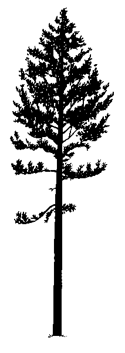

Lodgepole Pine (*Pinus contorta*)

Welcome to the Species Summary Dashboard for lodgepole pine (abbreviated as “Pl”), a place for species-specific summaries of the inputs and outputs of the Climate Change Informed Species Selection (CCISS) tool. This dashboard is intended to support forest practitioners, planners, and land managers, in making informed, forward-looking decisions about where Pl may be suitable to plant over the coming decades. As climate conditions shift, these decisions will become increasingly critical for maintaining productive, resilient, and adaptive forest landscapes.

At the top of the page, you will find tabs for the following summaries:

- **Reference (historical baseline) Period**
  - Maps and descriptive summary of the species range in British Columbia during the baseline climate normal period of 1961-1990 in terms of its environmental suitability across Biogeoclimatic (BGC) zones and across three edatopic (soil nutrient x moisture) regimes, relative to the local biogeoclimatic subzone:
    - Poor/subxeric (B2)
    - Mesic/zonal (C4)
    - Rich/hygric (D6)
- **CCISS Projections**
  - A collection of visualizations and interpretations of the CCISS tool projections through 2100 for this species in British Columbia, exploring the changes in its suitable range over time. This includes:
    - Projected persistence and expansion of its environmentally suitable area relative to its historically suitable range
    - Shifts in its suitability within each BGC zone
    - A summary of projected changes in particular areas of interest in BC
    - Projected changes along elevational gradients
- **Forest Health**
  - A summary of forest health considerations and concerns for this species, interpreted in light of CCISS projections
- **Additional Resources**
  - A collection of other tools, websites, and guides that provide additional information about this species, particularly covering background ecology and silvics information not summarized here

**Notes for Interpreting and Applying this Summary**

This dashboard is intended to provide a species-specific overview and interpretation of the data from the CCISS tool and does not represent management recommendations. Please see the CCISS Documentation tab > Decision Guidance section for more information on the appropriate and intended uses of these data.

[figure not shown]

**Reference period**

In the maps below, each color represents the species environmental suitability during the historical reference period* of 1961-90 as determined by expert ratings. Green represents a high suitability (E1 rating), blue represents moderate suitability (E2), yellow represents low suitability (E3), and white indicates areas that are unsuitable for the species. See [CCISS Documentation tab > Methods > Environmental Suitability Ratings](https://bcgov-ffec.ca/cciss-docs/Methods.html#environmental-suitability-ratings) for more detailed definitions and information on the expert rating process.

*Note on terminology: The historical reference period is sometimes referred to as the “baseline” or simply “historical” or “reference” period.

**Mesic/zonal (C4)**

Environmental Suitability in mesic/zonal (C4) edatopes under baseline climate (1961-1990)

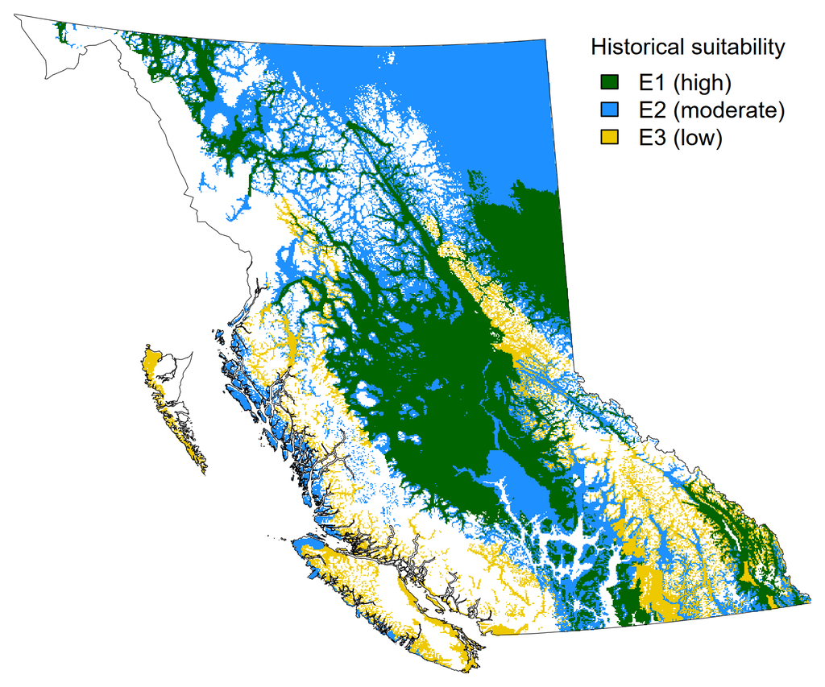

**Poor/subxeric (B2)**

Environmental Suitability in poor/subxeric (B2) edatopes under baseline climate (1961-1990)

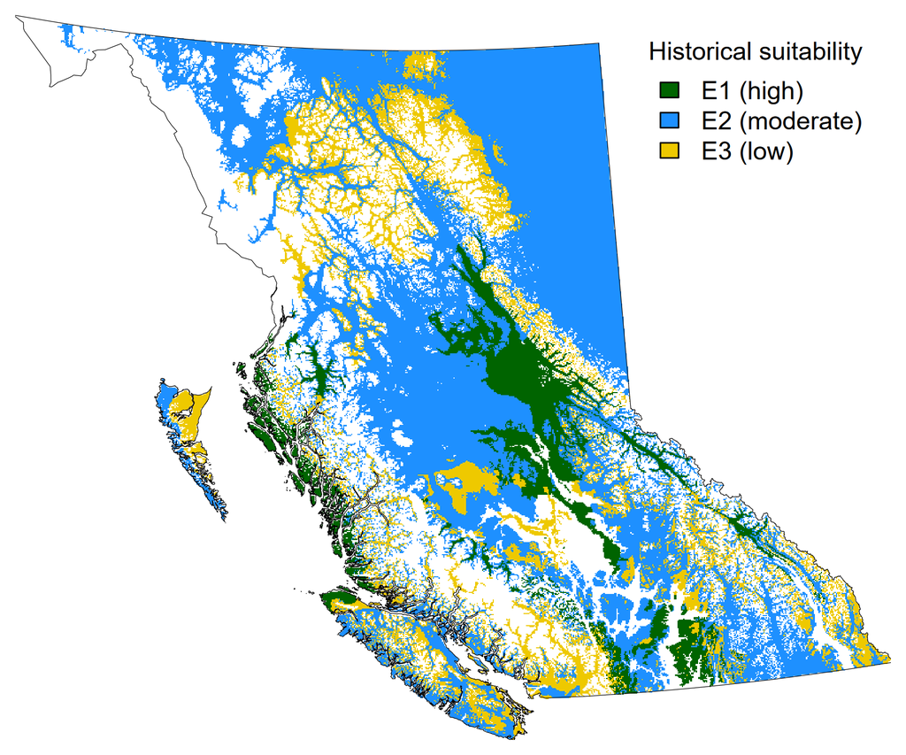

**Rich/hygric (D6)**

Environmental Suitability in rich/hygric (D6) edatopes under baseline climate (1961-1990)

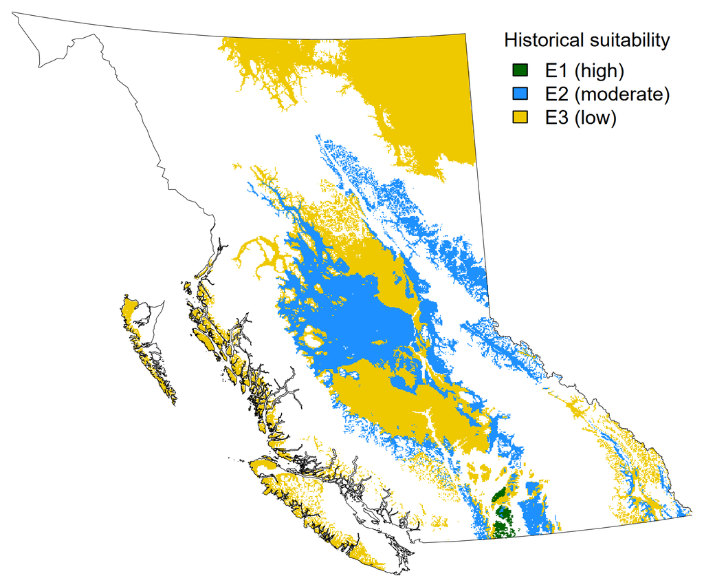

**Range by Biogeoclimatic Ecosystem Classification (BEC)**

How is the total environmentally suitable area of the province (all colored areas on the maps) split across Biogeoclimatic (BGC) zones? The pie chart to the right explores this by showing the total suitable area (Km<sup>2</sup>) of BC for lodgepole pine by BGC zone based on climates of the historical reference period (1961-1990).

*Summary of its prevalence within these BGC zones*

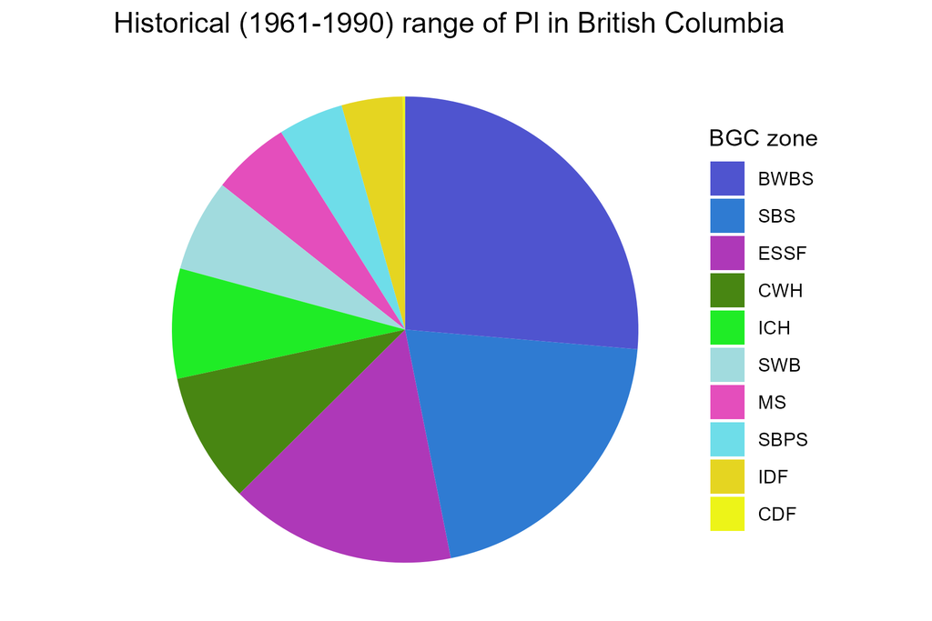

**Key to BGC zones:** [CCISS Documentation > Definitions](https://bcgov-ffec.ca/cciss-docs/Definitions.html#biogeoclimatic-ecosystem-classification-bec-codes)

**CCISS projections for lodgepole pine**

On this page, you will find a visual and interpretive synthesis of the CCISS tool projections for this species, including:

1. Proportion of the historic range that the species will remain environmentally suitable (i.e. persist) or become newly suitable (i.e. expand) by edatope.
2. Mean changes in environmental suitability across its geographic range in BC, by future time period and edatope.
3. Shifts in suitability across specific provincial biogeoclimatic (BGC) zones.

**Broad trends**

*Notes on interpretation of persistence and expansion*

Persistence (X axis) and Expansion (Y axis) are subtly different in how they relate to the historical range of the species:

$$\text{Persistence (\%)} =
\frac{\text{future suitable area within historical range of suitability}}
{\text{historically suitable area}}
\times 100$$
$$\text{Expansion (\%)} =
\frac{\text{future suitable area outside historical range of suitability}}
{\text{historically suitable area}}
\times 100$$

**Mesic/zonal (C4)**

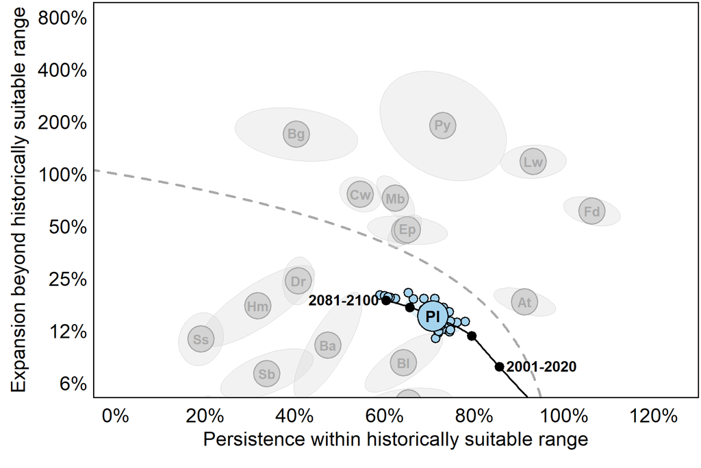

This figure shows the overall projected persistence and expansion of the suitability of lodgepole pine relative to its historically suitable range, in the SSP2–4.5 emission scenario given current policies for moderate emission mitigation. The black line shows the projected trajectory of change over time for this species, with black points representing each time period. The first and last time periods are labeled, and the model results for the 2041–2060 are emphasized (in blue) due to the relevance of this time period for management planning. The small colorful points represent simulation runs of the various global climate models (GCMs) used in the CCISS projections (Mahony et al. 2022). The large colorful point with the species abbreviation is the mean of the entire GCM ensemble for an edatope (B2: Poor/subxeric sites, C4: mesic/zonal sites, D6: rich/hygric sites) averaged across all BGC zones in the province. Other species are shown for reference in the background, as grey mean points and shaded ellipses representing the 1-standard deviation probability of the ensemble calculated for each point. The grey dashed line divides areas of the plot for which total feasible area is either growing (above the line) or shrinking (below the line). Note that all results exclude biogeoclimatic units that do not currently support commercially operable forest, and that expansion (the y-axis) is log-scaled. Because an edatope is relative to each BGC (e.g., a mesic site in the Coastal Western Hemlock (CWH) zone is relatively wetter than a mesic site in the Interior Douglas Fir (IDF)), it’s important to note that the amount of variation shown here are likely influenced by the underlying differences in magnitude of suitability across biogeoclimatic zones. Thus, this plot is meant to be a broad overview perspective by edatope across the entire province.

**Poor/subxeric (B2)**

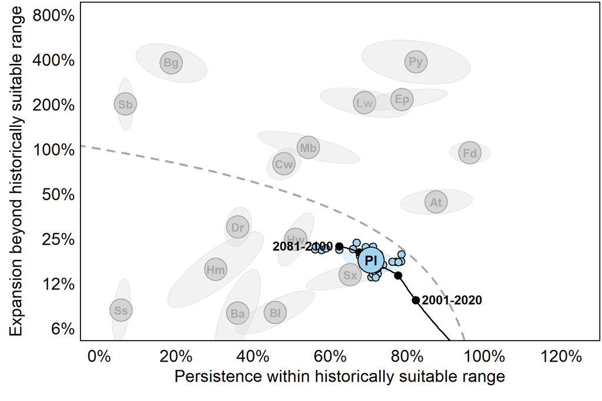

This figure shows the overall projected persistence and expansion of the suitability of lodgepole pine relative to its historically suitable range, in the SSP2–4.5 emission scenario given current policies for moderate emission mitigation. The black line shows the projected trajectory of change over time for this species, with black points representing each time period. The first and last time periods are labeled, and the model results for the 2041–2060 are emphasized (in blue) due to the relevance of this time period for management planning. The small colorful points represent simulation runs of the various global climate models (GCMs) used in the CCISS projections (Mahony et al. 2022). The large colorful point with the species abbreviation is the mean of the entire GCM ensemble for an edatope (B2: Poor/subxeric sites, C4: mesic/zonal sites, D6: rich/hygric sites) averaged across all BGC zones in the province. Other species are shown for reference in the background, as grey mean points and shaded ellipses representing the 1-standard deviation probability of the ensemble calculated for each point. The grey dashed line divides areas of the plot for which total feasible area is either growing (above the line) or shrinking (below the line). Note that all results exclude biogeoclimatic units that do not currently support commercially operable forest, and that expansion (the y-axis) is log-scaled. Because an edatope is relative to each BGC (e.g., a mesic site in the Coastal Western Hemlock (CWH) zone is relatively wetter than a mesic site in the Interior Douglas Fir (IDF)), it’s important to note that the amount of variation shown here are likely influenced by the underlying differences in magnitude of suitability across biogeoclimatic zones. Thus, this plot is meant to be a broad overview perspective by edatope across the entire province.

**Rich/hygric (D6)**

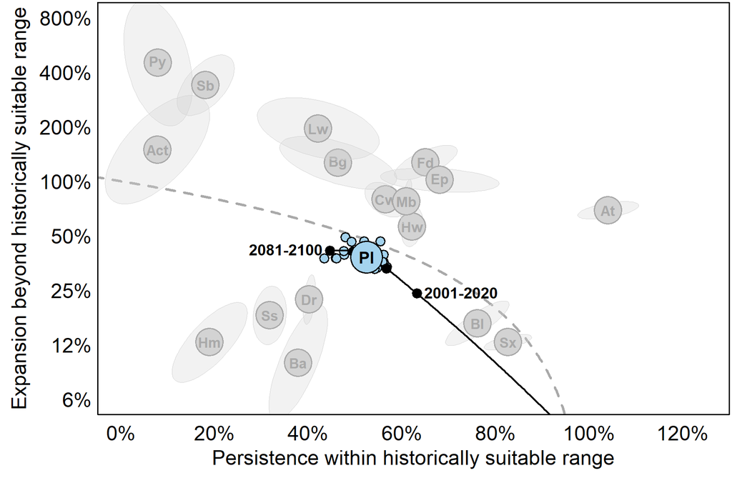

This figure shows the overall projected persistence and expansion of the suitability of lodgepole pine relative to its historically suitable range, in the SSP2–4.5 emission scenario given current policies for moderate emission mitigation. The black line shows the projected trajectory of change over time for this species, with black points representing each time period. The first and last time periods are labeled, and the model results for the 2041–2060 are emphasized (in blue) due to the relevance of this time period for management planning. The small colorful points represent simulation runs of the various global climate models (GCMs) used in the CCISS projections (Mahony et al. 2022). The large colorful point with the species abbreviation is the mean of the entire GCM ensemble for an edatope (B2: Poor/subxeric sites, C4: mesic/zonal sites, D6: rich/hygric sites) averaged across all BGC zones in the province. Other species are shown for reference in the background, as grey mean points and shaded ellipses representing the 1-standard deviation probability of the ensemble calculated for each point. The grey dashed line divides areas of the plot for which total feasible area is either growing (above the line) or shrinking (below the line). Note that all results exclude biogeoclimatic units that do not currently support commercially operable forest, and that expansion (the y-axis) is log-scaled. Because an edatope is relative to each BGC (e.g., a mesic site in the Coastal Western Hemlock (CWH) zone is relatively wetter than a mesic site in the Interior Douglas Fir (IDF)), it’s important to note that the amount of variation shown here are likely influenced by the underlying differences in magnitude of suitability across biogeoclimatic zones. Thus, this plot is meant to be a broad overview perspective by edatope across the entire province.

**Suitability changes**

Overall, the total suitable area in BC for lodgepole pine is projected to decrease with climate change, with large areas of its historic range projected to become unsuitable.

These patterns are shown in 20-year intervals and by Edatopic space in the figures to the right.

**Mesic/zonal (C4)**

**2001–2020**

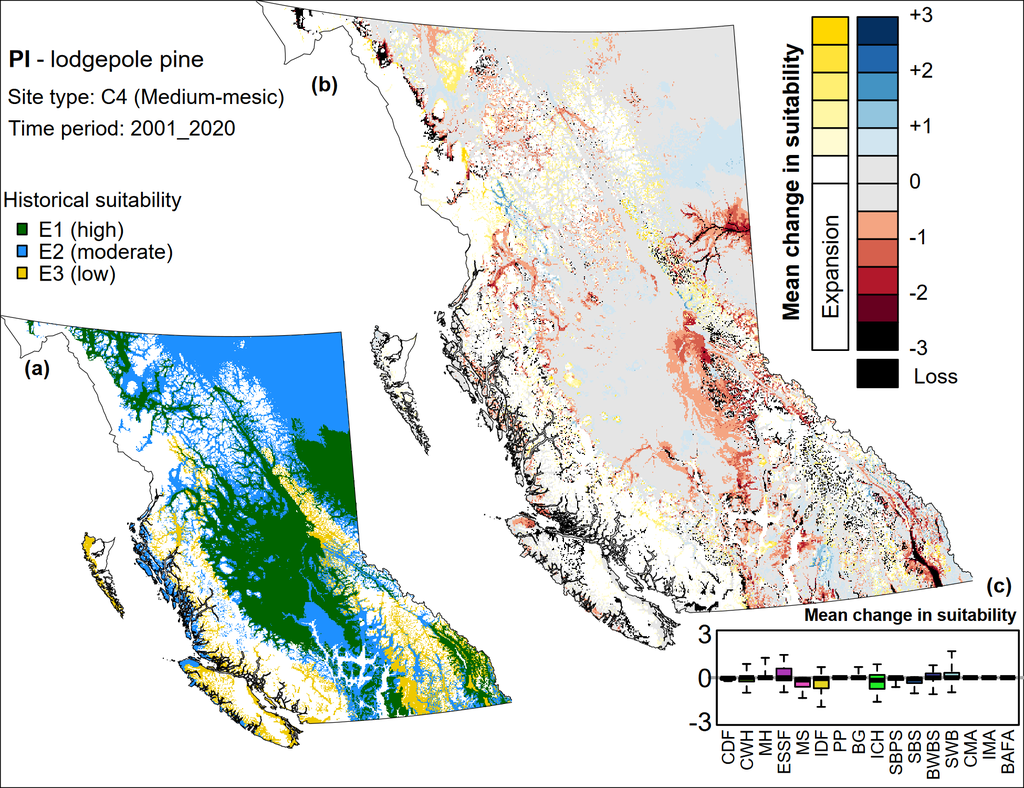

a) The species’ historical environmental suitability rating, during the historical reference period of 1961-90 as determined by expert ratings. b) Mean change in suitability from the reference period, with shades of yellow representing areas of new suitability, blue shades representing increased suitability, red shades representing decreased suitability, and black representing a complete loss of suitability. c) Overall mean changes in suitability ranking across the province, within each BGC zone; boxplot whiskers extend to the 5th and 95th percentiles.

**2021–2040**

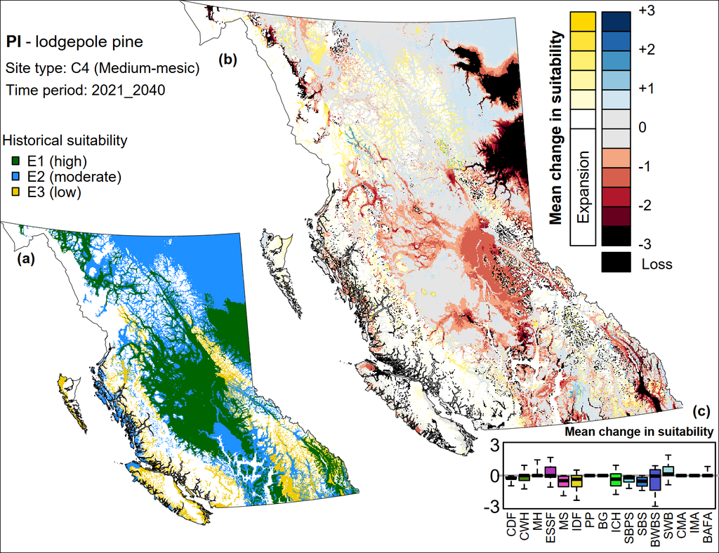

a) The species’ historical environmental suitability rating, during the historical reference period of 1961-90 as determined by expert ratings. b) Mean change in suitability from the reference period, with shades of yellow representing areas of new suitability, blue shades representing increased suitability, red shades representing decreased suitability, and black representing a complete loss of suitability. c) Overall mean changes in suitability ranking across the province, within each BGC zone; boxplot whiskers extend to the 5th and 95th percentiles.

**2041–2060**

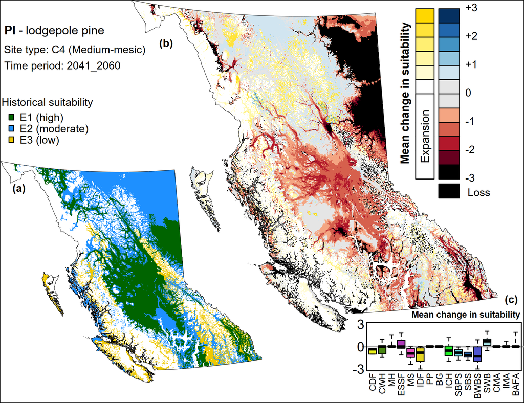

a) The species’ historical environmental suitability rating, during the historical reference period of 1961-90 as determined by expert ratings. b) Mean change in suitability from the reference period, with shades of yellow representing areas of new suitability, blue shades representing increased suitability, red shades representing decreased suitability, and black representing a complete loss of suitability. c) Overall mean changes in suitability ranking across the province, within each BGC zone; boxplot whiskers extend to the 5th and 95th percentiles.

**2061–2080**

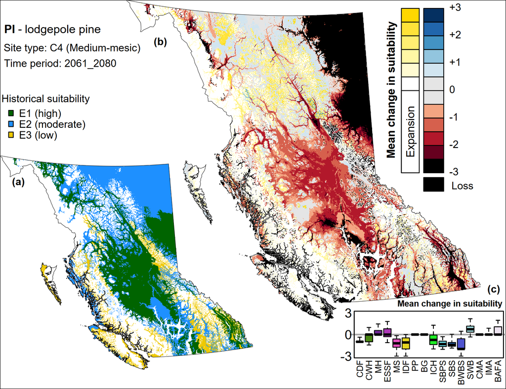

a) The species’ historical environmental suitability rating, during the historical reference period of 1961-90 as determined by expert ratings. b) Mean change in suitability from the reference period, with shades of yellow representing areas of new suitability, blue shades representing increased suitability, red shades representing decreased suitability, and black representing a complete loss of suitability. c) Overall mean changes in suitability ranking across the province, within each BGC zone; boxplot whiskers extend to the 5th and 95th percentiles.

**2081–2100**

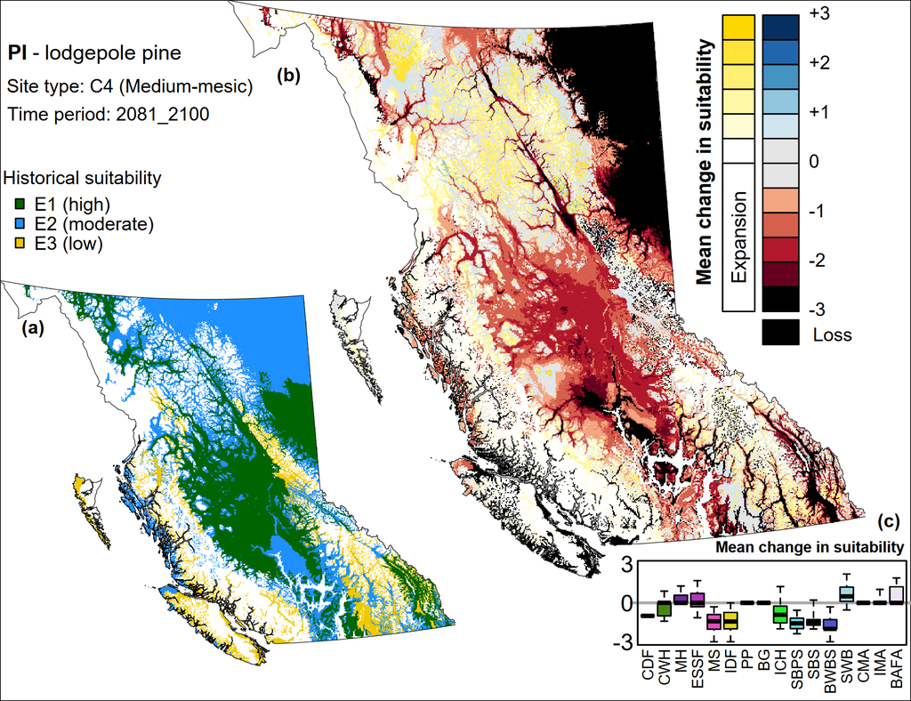

a) The species’ historical environmental suitability rating, during the historical reference period of 1961-90 as determined by expert ratings. b) Mean change in suitability from the reference period, with shades of yellow representing areas of new suitability, blue shades representing increased suitability, red shades representing decreased suitability, and black representing a complete loss of suitability. c) Overall mean changes in suitability ranking across the province, within each BGC zone; boxplot whiskers extend to the 5th and 95th percentiles.

**Poor/subxeric (B2)**

**2001–2020**

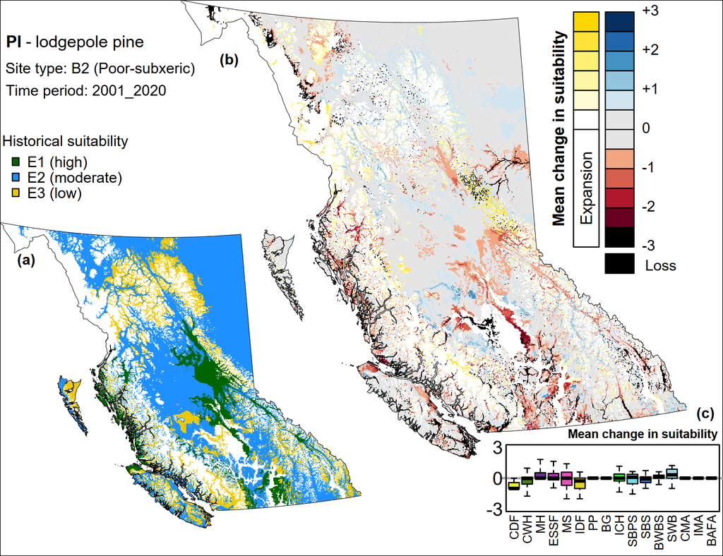

a) The species’ historical environmental suitability rating, during the historical reference period of 1961-90 as determined by expert ratings. b) Mean change in suitability from the reference period, with shades of yellow representing areas of new suitability, blue shades representing increased suitability, red shades representing decreased suitability, and black representing a complete loss of suitability. c) Overall mean changes in suitability ranking across the province, within each BGC zone; boxplot whiskers extend to the 5th and 95th percentiles.

**2021–2040**

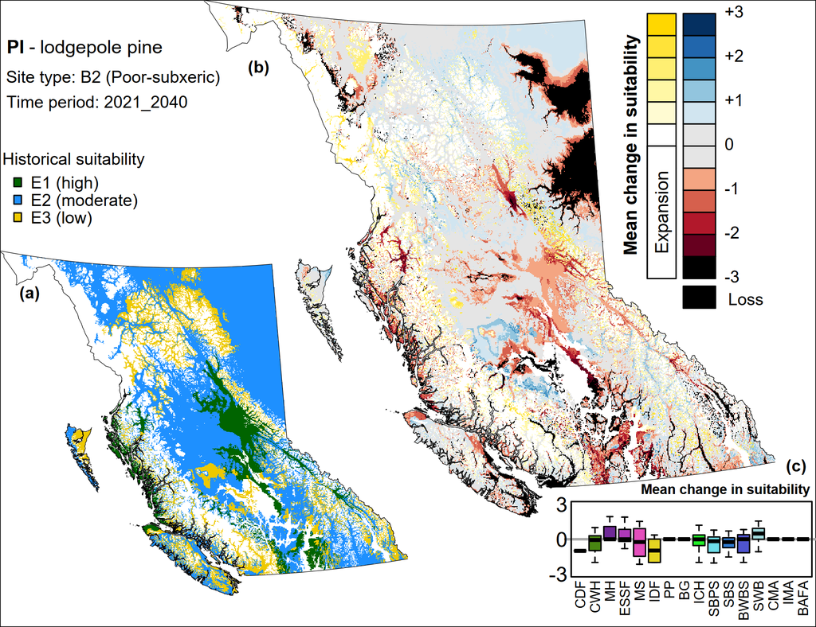

a) The species’ historical environmental suitability rating, during the historical reference period of 1961-90 as determined by expert ratings. b) Mean change in suitability from the reference period, with shades of yellow representing areas of new suitability, blue shades representing increased suitability, red shades representing decreased suitability, and black representing a complete loss of suitability. c) Overall mean changes in suitability ranking across the province, within each BGC zone; boxplot whiskers extend to the 5th and 95th percentiles.

**2041–2060**

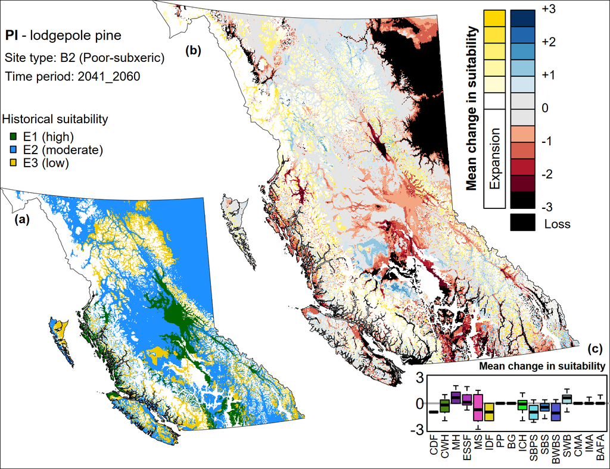

a) The species’ historical environmental suitability rating, during the historical reference period of 1961-90 as determined by expert ratings. b) Mean change in suitability from the reference period, with shades of yellow representing areas of new suitability, blue shades representing increased suitability, red shades representing decreased suitability, and black representing a complete loss of suitability. c) Overall mean changes in suitability ranking across the province, within each BGC zone; boxplot whiskers extend to the 5th and 95th percentiles.

**2061–2080**

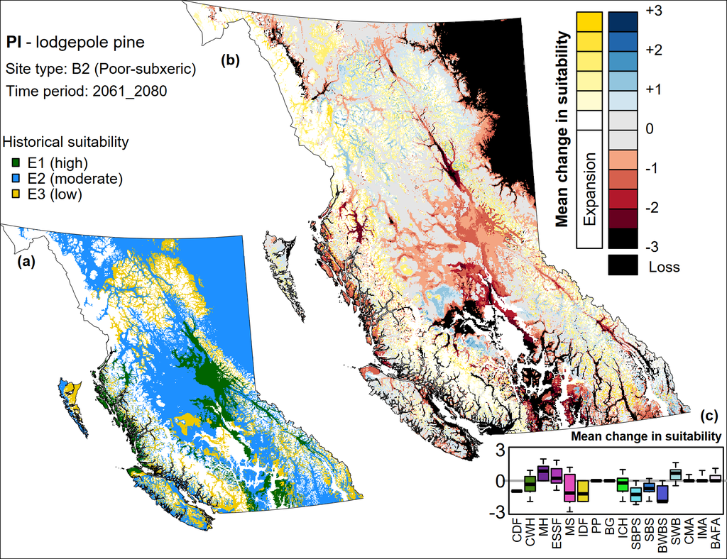

a) The species’ historical environmental suitability rating, during the historical reference period of 1961-90 as determined by expert ratings. b) Mean change in suitability from the reference period, with shades of yellow representing areas of new suitability, blue shades representing increased suitability, red shades representing decreased suitability, and black representing a complete loss of suitability. c) Overall mean changes in suitability ranking across the province, within each BGC zone; boxplot whiskers extend to the 5th and 95th percentiles.

**2081–2100**

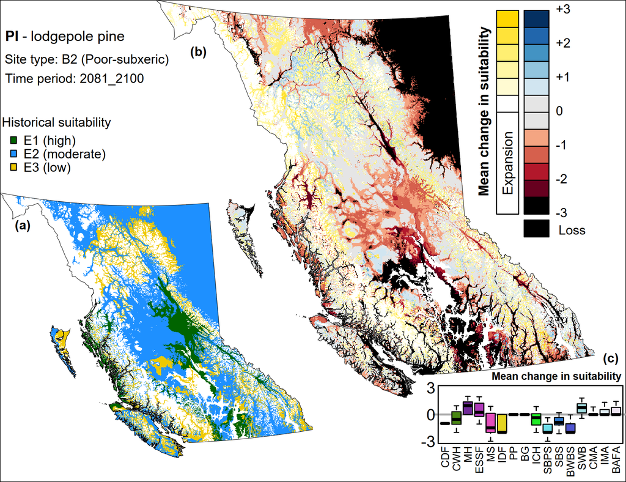

a) The species’ historical environmental suitability rating, during the historical reference period of 1961-90 as determined by expert ratings. b) Mean change in suitability from the reference period, with shades of yellow representing areas of new suitability, blue shades representing increased suitability, red shades representing decreased suitability, and black representing a complete loss of suitability. c) Overall mean changes in suitability ranking across the province, within each BGC zone; boxplot whiskers extend to the 5th and 95th percentiles.

**Rich/hygric (D6)**

**2001–2020**

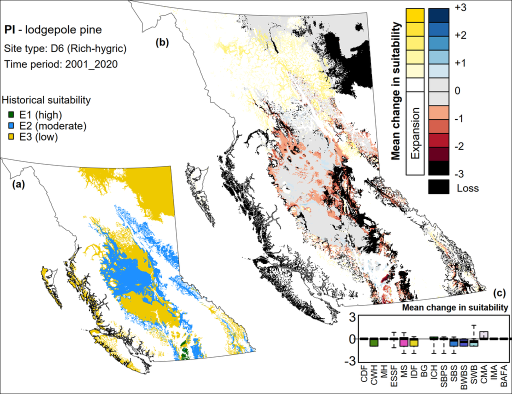

a) The species’ historical environmental suitability rating, during the historical reference period of 1961-90 as determined by expert ratings. b) Mean change in suitability from the reference period, with shades of yellow representing areas of new suitability, blue shades representing increased suitability, red shades representing decreased suitability, and black representing a complete loss of suitability. c) Overall mean changes in suitability ranking across the province, within each BGC zone; boxplot whiskers extend to the 5th and 95th percentiles.

**2021–2040**

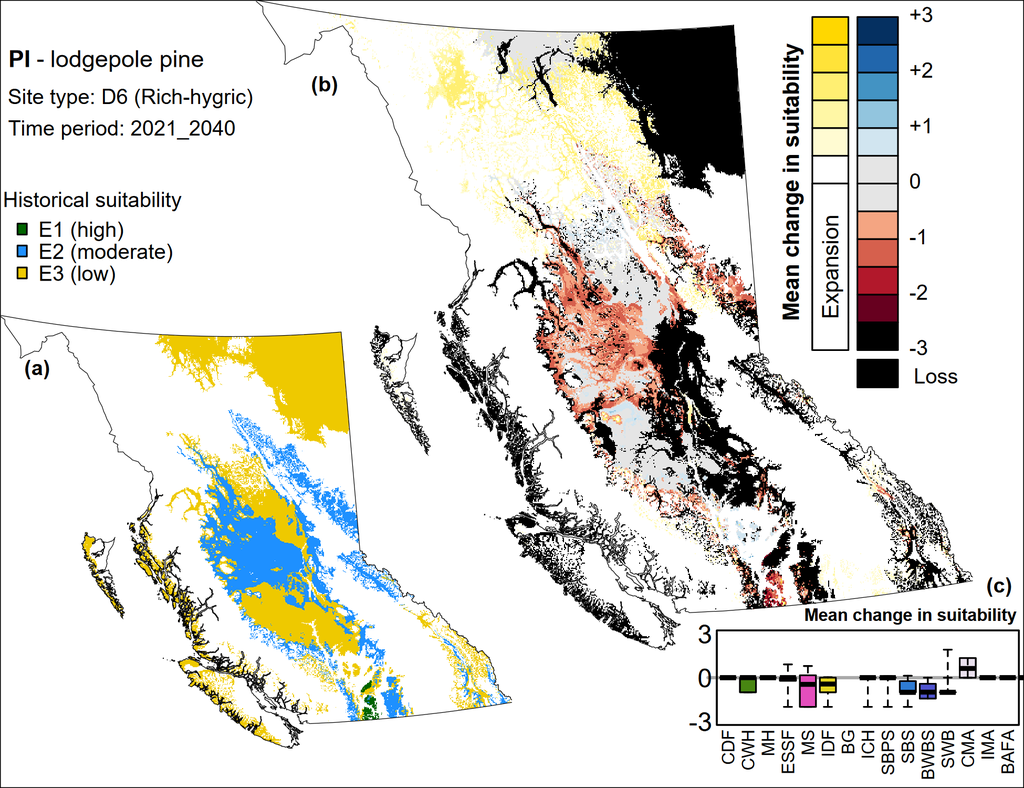

a) The species’ historical environmental suitability rating, during the historical reference period of 1961-90 as determined by expert ratings. b) Mean change in suitability from the reference period, with shades of yellow representing areas of new suitability, blue shades representing increased suitability, red shades representing decreased suitability, and black representing a complete loss of suitability. c) Overall mean changes in suitability ranking across the province, within each BGC zone; boxplot whiskers extend to the 5th and 95th percentiles.

**2041–2060**

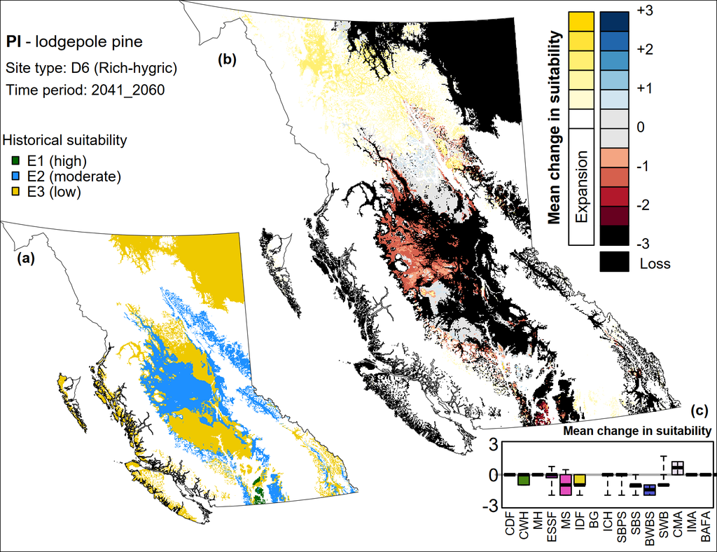

a) The species’ historical environmental suitability rating, during the historical reference period of 1961-90 as determined by expert ratings. b) Mean change in suitability from the reference period, with shades of yellow representing areas of new suitability, blue shades representing increased suitability, red shades representing decreased suitability, and black representing a complete loss of suitability. c) Overall mean changes in suitability ranking across the province, within each BGC zone; boxplot whiskers extend to the 5th and 95th percentiles.

**2061–2080**

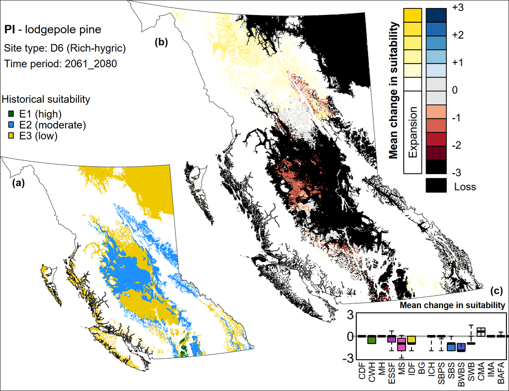

a) The species’ historical environmental suitability rating, during the historical reference period of 1961-90 as determined by expert ratings. b) Mean change in suitability from the reference period, with shades of yellow representing areas of new suitability, blue shades representing increased suitability, red shades representing decreased suitability, and black representing a complete loss of suitability. c) Overall mean changes in suitability ranking across the province, within each BGC zone; boxplot whiskers extend to the 5th and 95th percentiles.

**2081–2100**

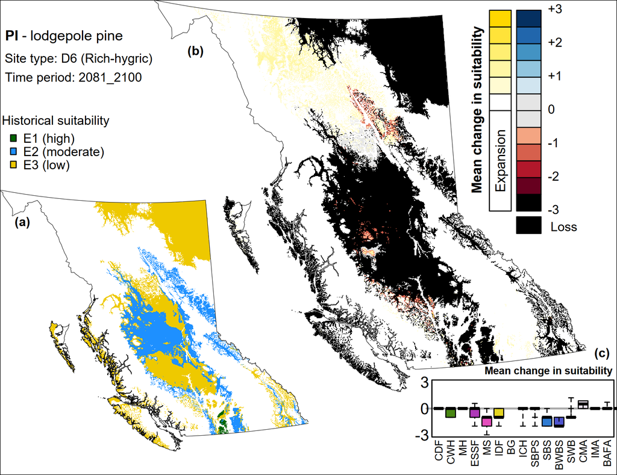

a) The species’ historical environmental suitability rating, during the historical reference period of 1961-90 as determined by expert ratings. b) Mean change in suitability from the reference period, with shades of yellow representing areas of new suitability, blue shades representing increased suitability, red shades representing decreased suitability, and black representing a complete loss of suitability. c) Overall mean changes in suitability ranking across the province, within each BGC zone; boxplot whiskers extend to the 5th and 95th percentiles.

**Shifts in suitable area**

**Mesic/zonal (C4)**

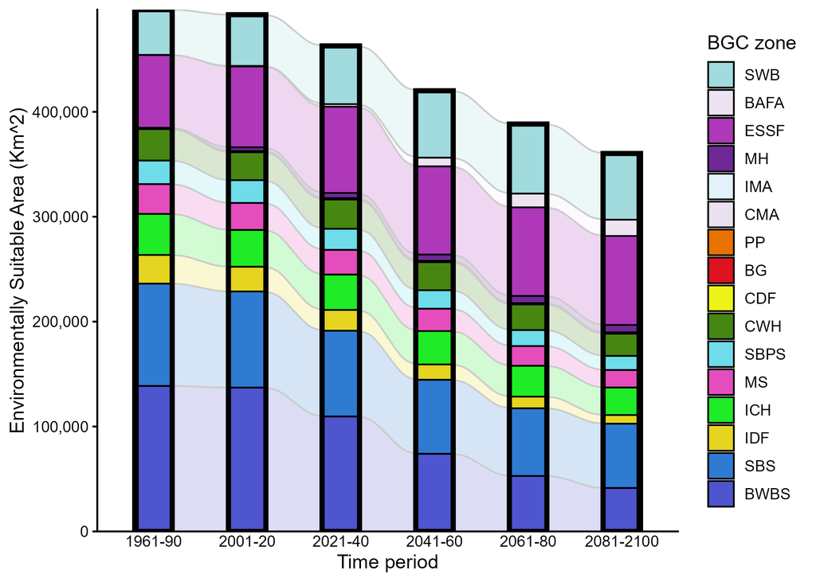

This figure shows the projected changes in lodgepole pine’s suitable area in BC (Km<sup>2</sup>) over time by biogeoclimatic zone (colors) within the three representative edatopes (mesic/zonal C4, poor/subxeric B2, and rich/hygric D6; tabs). The height of each bar represents the total environmentally suitable area for Pl in each time period, distributed across the different BGC zones. The first time period shown on the left of each graph is the historical reference period (1961-1990), where environmental suitability is determined by expert ratings (see Reference tab). The remaining time periods are based on CCISS model projections incorporating environmental suitability (from the reference period) and future climate data. It is important to remember that for the future projected time periods, the relative areas of BGC zones remain static within the province (e.g., they are not shrinking or growing). Rather, this reflects changes in the projected spatial distribution of climate types that may be more or less suitable for the focal species, representing changes in suitable area across these static zones.

**Key to BGC zones:** [CCISS Documentation > Definitions](https://bcgov-ffec.ca/cciss-docs/Definitions.html#biogeoclimatic-ecosystem-classification-bec-codes)

**Poor/subxeric (B2)**

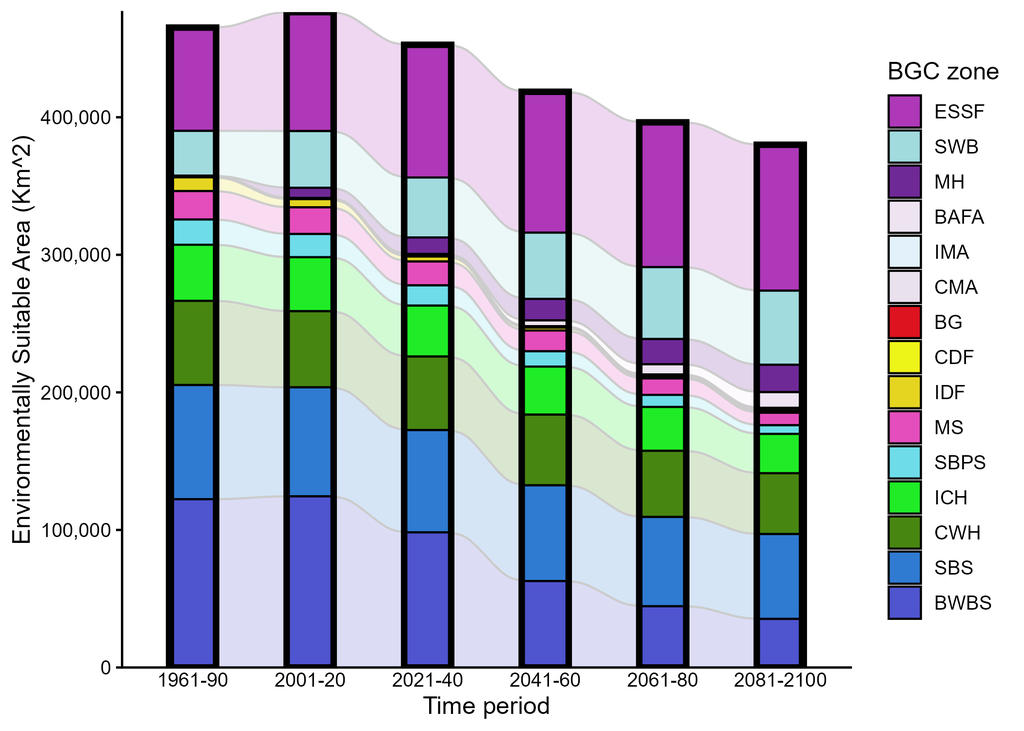

This figure shows the projected changes in lodgepole pine’s suitable area in BC (Km<sup>2</sup>) over time by biogeoclimatic zone (colors) within the three representative edatopes (mesic/zonal C4, poor/subxeric B2, and rich/hygric D6; tabs). The height of each bar represents the total environmentally suitable area for Pl in each time period, distributed across the different BGC zones. The first time period shown on the left of each graph is the historical reference period (1961-1990), where environmental suitability is determined by expert ratings (see Reference tab). The remaining time periods are based on CCISS model projections incorporating environmental suitability (from the reference period) and future climate data. It is important to remember that for the future projected time periods, the relative areas of BGC zones remain static within the province (e.g., they are not shrinking or growing). Rather, this reflects changes in the projected spatial distribution of climate types that may be more or less suitable for the focal species, representing changes in suitable area across these static zones.

**Key to BGC zones:** [CCISS Documentation > Definitions](https://bcgov-ffec.ca/cciss-docs/Definitions.html#biogeoclimatic-ecosystem-classification-bec-codes)

**Rich/hygric (D6)**

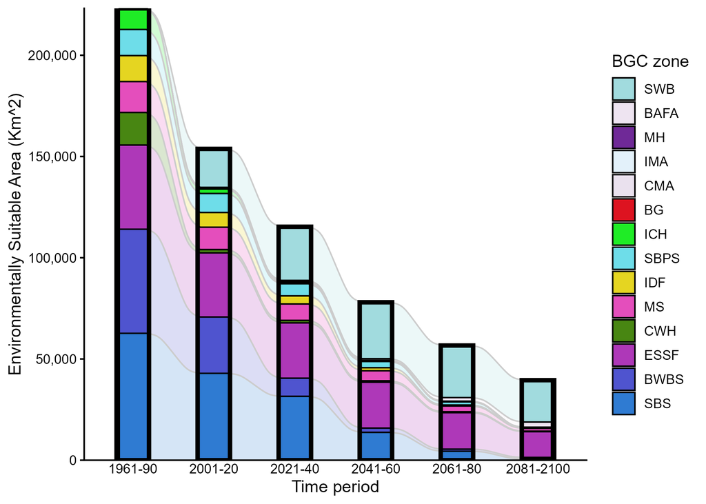

This figure shows the projected changes in lodgepole pine’s suitable area in BC (Km<sup>2</sup>) over time by biogeoclimatic zone (colors) within the three representative edatopes (mesic/zonal C4, poor/subxeric B2, and rich/hygric D6; tabs). The height of each bar represents the total environmentally suitable area for Pl in each time period, distributed across the different BGC zones. The first time period shown on the left of each graph is the historical reference period (1961-1990), where environmental suitability is determined by expert ratings (see Reference tab). The remaining time periods are based on CCISS model projections incorporating environmental suitability (from the reference period) and future climate data. It is important to remember that for the future projected time periods, the relative areas of BGC zones remain static within the province (e.g., they are not shrinking or growing). Rather, this reflects changes in the projected spatial distribution of climate types that may be more or less suitable for the focal species, representing changes in suitable area across these static zones.

**Key to BGC zones:** [CCISS Documentation > Definitions](https://bcgov-ffec.ca/cciss-docs/Definitions.html#biogeoclimatic-ecosystem-classification-bec-codes)

**Works Cited**

Mahony, Colin R., Tongli Wang, Andreas Hamann, and Alex J. Cannon. 2022. “A Global Climate Model Ensemble for Downscaled Monthly Climate Normals over North America.” *International Journal of Climatology* 42 (11): 5871–91. https://doi.org/https://doi.org/10.1002/joc.7566.